# Has Scottish Obesity Prevalence Changed over the Years and do Different Factors Effect this

Author

Jo Scott-Stephen, Eleanor Mills and Sophie Brown

# 1 Introduction

# 2 Exploratory Analysis

# 3 Formal Analysis

Since our response variable is binary, we fit a logistic regression model.

$$Obese \sim Bernoulli(p_i)$$

Where $p_i$ is the probability of being obese

$$logit(p_i)= \alpha + \beta_{\text{sex}}\cdot\mathbb{I}_{\text{sex}} + \beta_{\text{year}}\cdot\text{Year} + \beta_{\text{fv}}\cdot\mathbb{I}_{\text{FV}} + \beta_{\text{middle-aged}}\cdot\mathbb{I}_{\text{middle-aged}} + \beta_{\text{old}}\cdot\mathbb{I}_{\text{old}} + \beta_{retired}\cdot\mathbb{I}_{\text{retired}} + \beta_{unemployed}\cdot\mathbb{I}_{\text{unemployed}}$$

where

- $\alpha$ is the intercept (the baseline log-odds of obesity when all predictors are at their reference category),
- $\beta_\text{sex}$ is the coefficient for sex,
- $\beta_\text{year}$ is the coefficient for survey year,
- $\beta_\text{fv}$ is the coefficient for whether an individual consumes the daily intake of either fruit, vegetables or both,
- $\beta_\text{middle-aged}$ is the coefficient for being middle-aged (35-64 years old),
- $\beta_\text{old}$ is the coefficient for being old (65+ years),
- $\beta_\text{retired}$ is the coefficient for being retired,
- $\beta_\text{unemployed}$ is the coefficient for being unemployed or in another non-working status,
- $\mathbb{I}_{\text{sex}}(x)$ is an indicator function such that

$$\mathbb{I}_{\mbox{male}}(x) =
\begin{cases}
1 & \mbox{if gender of } x \mbox{ is male}, \\
0 & \mbox{if gender of } x \mbox{ is female}.
\end{cases}$$

- $\mathbb{I}_{\text{FV}}(x)$ is an indicator function such that

$$\mathbb{I}_{\mbox{FV}}(x) =
\begin{cases}
1 & \mbox{if } x \mbox{ consumes the recommended daily intake of fruit and/or vegetables}, \\
0 & \mbox{otherwise}.
\end{cases}$$

- $\mathbb{I}_{\text{middle-aged}}(x)$ is an indicator function such that

$$\mathbb{I}_{\mbox{middle-aged}}(x) =
\begin{cases}
1 & \mbox{if } x \mbox{ is middle-aged (35-64 years old)}, \\
0 & \mbox{otherwise}.
\end{cases}$$

- $\mathbb{I}_{\text{old}}(x)$ is an indicator function such that

$$\mathbb{I}_{\mbox{old}}(x) =
\begin{cases}
1 & \mbox{if } x \mbox{ is old (65+ years old)}, \\
0 & \mbox{otherwise}.
\end{cases}$$

- $\mathbb{I}_{\text{retired}}(x)$ is an indicator function such that

$$\mathbb{I}_{\mbox{retired}}(x) =
\begin{cases}
1 & \mbox{if } x \mbox{ is retired}, \\
0 & \mbox{otherwise}.
\end{cases}$$

- $\mathbb{I}_{\text{unemployed}}(x)$ is an indicator function such that

$$\mathbb{I}_{\mbox{unemployed}}(x) =
\begin{cases}
1 & \mbox{if } x \mbox{ is unemployed or in another non-working status}, \\
0 & \mbox{otherwise}.
\end{cases}$$

Table 1: Estimates of the fitted model’s coefficients.

| Term | Estimate (to 3 d.p.) | p-value (to 4 d.p.) |
| --- | --- | --- |
| Intercept | 1.723 | 0.9591 |
| Sex Male | -0.104 | 0.0056 |
| Year | -0.001 | 0.9289 |
| FV yes | -0.070 | 0.2416 |
| Middle-aged | 0.570 | 0.0000 |
| Old | 0.631 | 0.0000 |
| Retired | 0.104 | 0.1528 |
| Unemployed / Other | 0.394 | 0.0000 |

Table 1 displays the fitted values from out model. From this we can see that year, fruit and vegetables and retirement all have large p-values, signifying these are not significant. We will plot a ROC curve of our model to assess the goodness of fit.

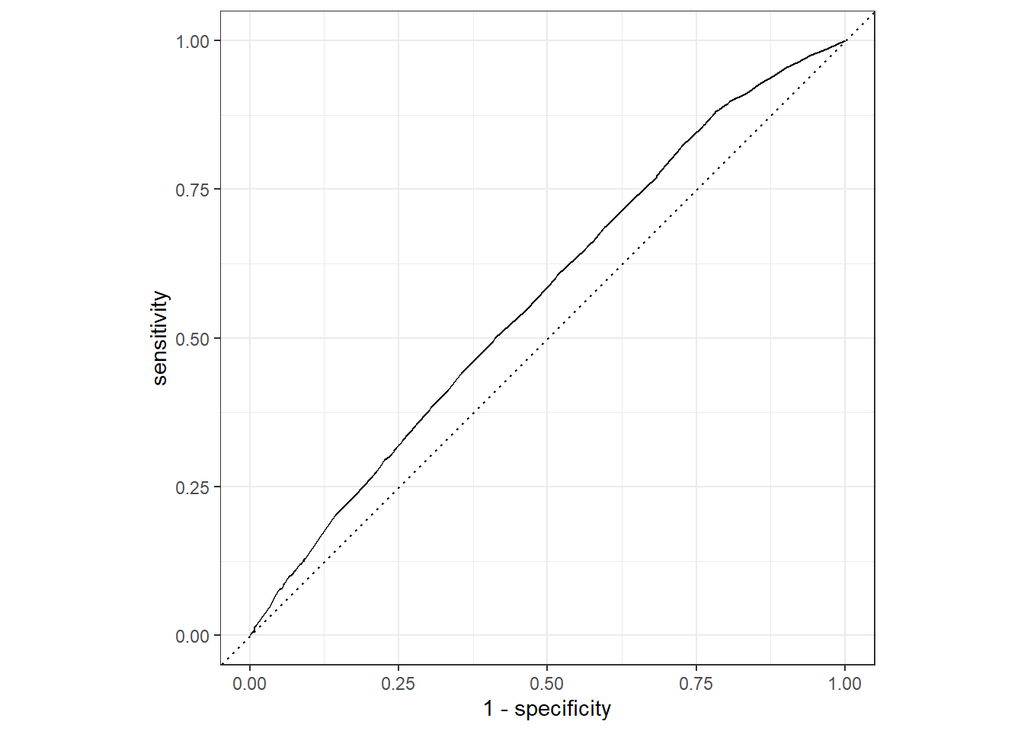

Figure 1: ROC curve for socioeconomic model

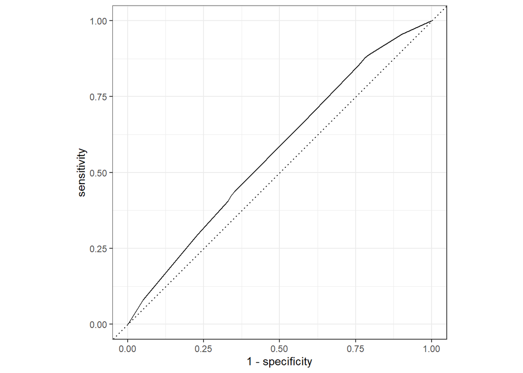

# 4 Conclusions